# Analysis of Fatalities, injuries and damage caused by severe weather events

## Synopsis

Based on recorded storm data from 1950 through 2011, this document tries to provide some insight into the effects of severe weather on the public. These kinds of answers can be beneficial to plan responses to severe weather events and to prepare contingency plans.

# Data Processing

Load the libraries we will need:

```r
library(ggplot2)
library(maps)
library(mapproj)
```

Our data is derived from the [NOAA Storm Database](https://d396qusza40orc.cloudfront.net/repdata%2Fdata%2FStormData.csv.bz2).  
Read in the data, mapping as many fields to numerical fields as possible. We are not converting the dates at this point, as we do not need the dates in our analysis. More information about the data file is available from the National Weather Service [Storm Data Documentation](https://d396qusza40orc.cloudfront.net/repdata%2Fpeer2_doc%2Fpd01016005curr.pdf).

```r
data <- read.csv("repdata_data_StormData.csv.bz2", header = TRUE, sep = ",",
    colClasses = c("numeric", "character", "character", "character", "numeric",
        "character", "character", "character", "numeric", "character", "character",
        "character", "character", "numeric", "character", "character", "character",
        "character", "numeric", "numeric", "character", "numeric", "numeric",
        "numeric", "numeric", "character", "numeric", "character", "character",
        "character", "character", "numeric", "numeric", "numeric", "numeric",
        "character", "numeric"))
```

The initial set has 902,297 observations. We first throw away all data that does not contain information we are interested in by filtering out data that did not cause fatalities, injuries or damage.

```r
smallData <- data[data$FATALITIES > 0 | data$INJURIES > 0 | data$PROPDMG > 0 |
    data$CROPDMG > 0, ]
```

This leaves us with 254,633 observations.

The EVTYPE fields contains a large number of errors and issues. In order to report on the data, we will add an additional column named category that contains the event category as used by the NCDC: - convection  
- extreme temperature - flood - marine - tropical cyclon - winter - other This is also the order of importance with which we will treat the various events. Convection events are the most important, so this order will also decide the tie-breaker if an event belongs to more than one category.

```r
convection <- c("?.*LIGHTING|LIGHTN|LIGNTNING|TORNADO|TORNDAO|WIND|TSTM|THUNDER|WND|HAIL|TURBULENCE|GUSTNADO?.*")
temperature <- c("?.*COLD|HEAT|WARM|TEMPERATURE|THERMIA?.*")
flood <- c("?.*FLOOD|RISING|STREAM FLD?.*")
marine <- c("?.*COASTAL|TSUNAMI|CURRENT|SWELLS|TIDE|WAVE|SEAS|SURF|HIGH WATER?.*")
cyclones <- c("?.*CYCLONE|HURRICANE|TYPHOON?.*")
winter <- c("?.*WINT|ICE|AVALAN|SLEET|SNOW|FREEZ|BLIZZ|FROST|GLAZE|MIXED?.*")

smallData[grepl(winter, smallData$EVTYPE, ignore.case = TRUE), "category"] = "Winter"
smallData[grepl(cyclones, smallData$EVTYPE, ignore.case = TRUE), "category"] = "Tropical Cyclones"
smallData[grepl(marine, smallData$EVTYPE, ignore.case = TRUE), "category"] = "Marine"
smallData[grepl(flood, smallData$EVTYPE, ignore.case = TRUE), "category"] = "Flood"
smallData[grepl(temperature, smallData$EVTYPE, ignore.case = TRUE), "category"] = "Extreme Temperatures"
smallData[grepl(convection, smallData$EVTYPE, ignore.case = TRUE), "category"] = "Convection"
smallData[is.na(smallData$category), "category"] = "Other"
```

The PROPDMG and CROPDMG fields need some conversion before we can do math on them. Here is the code for that. We add two extra columns that contain the property and crop damage.

```r
smallData$propertydamageEXP = 1
smallData[grepl("h|H", smallData$PROPDMGEXP, ignore.case = TRUE), "propertydamageEXP"] = 100
smallData[grepl("k|K", smallData$PROPDMGEXP, ignore.case = TRUE), "propertydamageEXP"] = 1000
smallData[grepl("m|M", smallData$PROPDMGEXP, ignore.case = TRUE), "propertydamageEXP"] = 1e+06
smallData[grepl("b|B", smallData$PROPDMGEXP, ignore.case = TRUE), "propertydamageEXP"] = 1e+09
smallData$propertydamage = smallData$PROPDMG * smallData$propertydamageEXP

smallData$cropdamageEXP = 1
smallData[grepl("k|K", smallData$CROPDMGEXP, ignore.case = TRUE), "cropdamageEXP"] = 1000
smallData[grepl("m|M", smallData$CROPDMGEXP, ignore.case = TRUE), "cropdamageEXP"] = 1e+06
smallData[grepl("b|B", smallData$CROPDMGEXP, ignore.case = TRUE), "cropdamageEXP"] = 1e+09
smallData$cropdamage = smallData$CROPDMG * smallData$cropdamageEXP
```

Having gone through the steps above, we now have clean dataset containing all the information to perform exploratory data analysis.

## Exploratory Data Analysis

We begin by exploring all the variables in the data set. ### Univariate Plots

```r
county<-table(smallData$COUNTYNAME)
out=data.frame(item=names(unlist(county)),count=unlist(county)[],
                stringsAsFactors=FALSE)
```

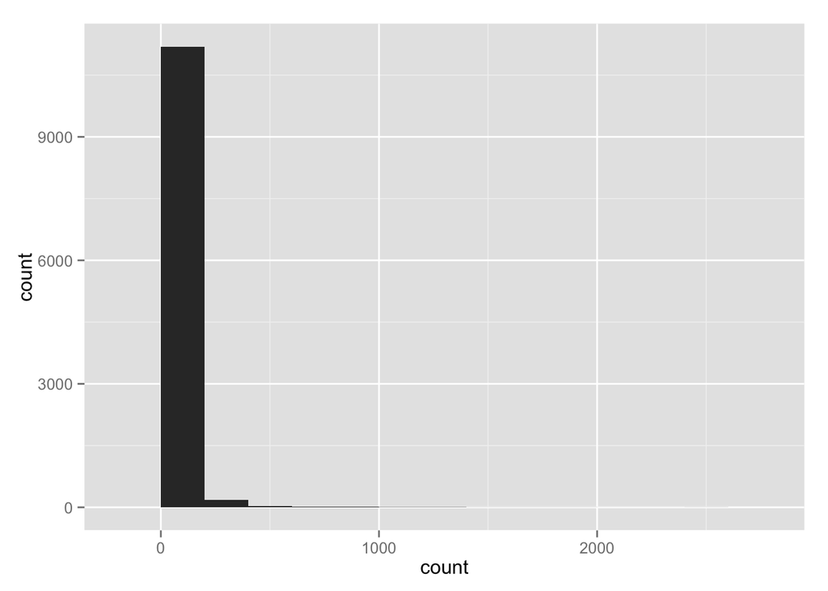

```r
ggplot(out, aes(x=count)) + geom_histogram(binwidth=200)
```

Figure above shows the frequency graph of number of events occuring in the respective counties. The mean value of frequence of occurence is around 22, thus showing that on an average you can expect a place to have an event occuring 22 time over the years between 1950-2011. Let’s have a closer look at the regions with lot of events occuring in this time span.

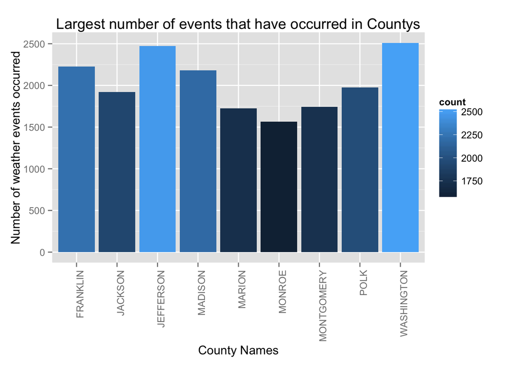

```r
maxregions<-subset(out,out$count>1500)
ggplot(maxregions, aes(x=item, y = count, fill = count))+theme(axis.text.x = element_text(angle = 90, hjust = 1))+geom_bar(stat="identity")+xlab("County Names")+ylab("Number of weather events occurred")+ggtitle("Largest number of events that have occurred in Countys")
```

The County of Washington has the highest number of weather events that has occurred over these years. Let’s now have a close look as to what events have taken place most in washington as per the category we have assigned.

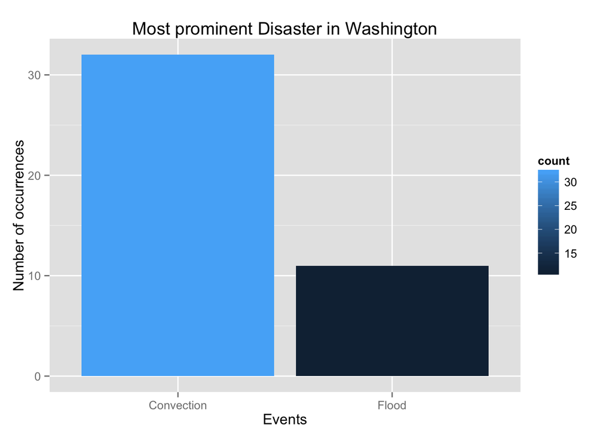

```r
washington2<-subset(smallData, COUNTYNAME == "WASHINGTON" & FATALITIES > 0)
washington1<-table(washington2$category)

washington<-data.frame(events=names(unlist(washington1)), count = unlist(washington1)[], stringsAsFactors = FALSE)

ggplot(washington, aes(x=events, y = count, fill = count))+geom_bar(stat="identity")+xlab("Events")+ylab("Number of occurrences")+ggtitle("Most prominent Disaster in Washington")
```

```r
table(washington$category)
```

```
## < table of extent 0 >
```

Breaking our category variable into individual events, we get the following result

```r
table(washington2$EVTYPE)
```

```
##
## FLASH FLOOD       FLOOD   LIGHTNING     TORNADO   TSTM WIND
##           7           4           6          22           4
```

Lets now look at some box plots of few variables:

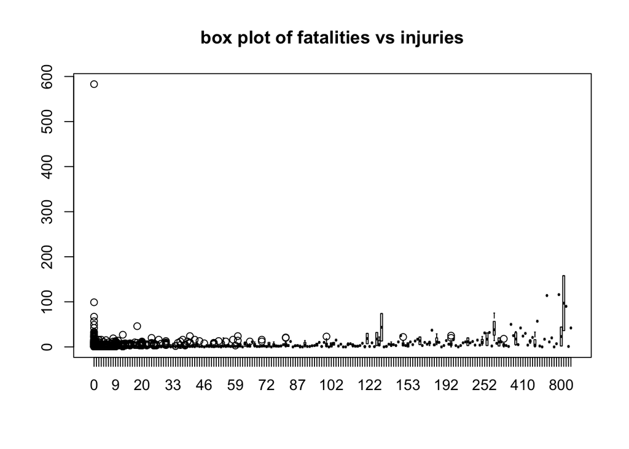

```r
boxplot(FATALITIES ~ INJURIES, data=smallData,main="box plot of fatalities vs injuries", ylab("fatalities"),xlab("Injuries"))
```

We can further get details of mean,median and other summary data of fatalities and injuries which contribute to the population damage

```r
summary(smallData$FATALITIES)
```

```
##     Min.  1st Qu.   Median     Mean  3rd Qu.     Max.
##   0.0000   0.0000   0.0000   0.0595   0.0000 583.0000
```

```r
summary(smallData$INJURIES)
```

```
##      Min.   1st Qu.    Median      Mean   3rd Qu.      Max.
##    0.0000    0.0000    0.0000    0.5519    0.0000 1700.0000
```

## Bivariate Plots

Let’s look at a few scatter plots to identify - if there is any kind of relationship present between a few features.

We begin by comparing two features i.e fatalities and injuries. We get the following result:

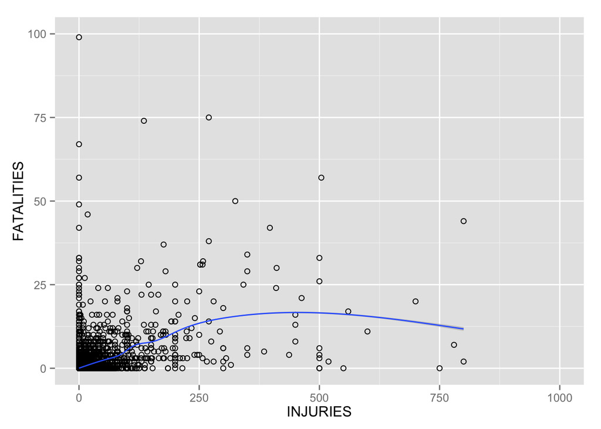

```r
ggplot(smallData, aes(x=INJURIES,y=FATALITIES))+geom_point(shape=1)+geom_smooth()+scale_y_continuous(limits = c(0,100)) + scale_x_continuous(limits = c(0,1000))
```

Let’s look at the relationship between property damage and crop damage:

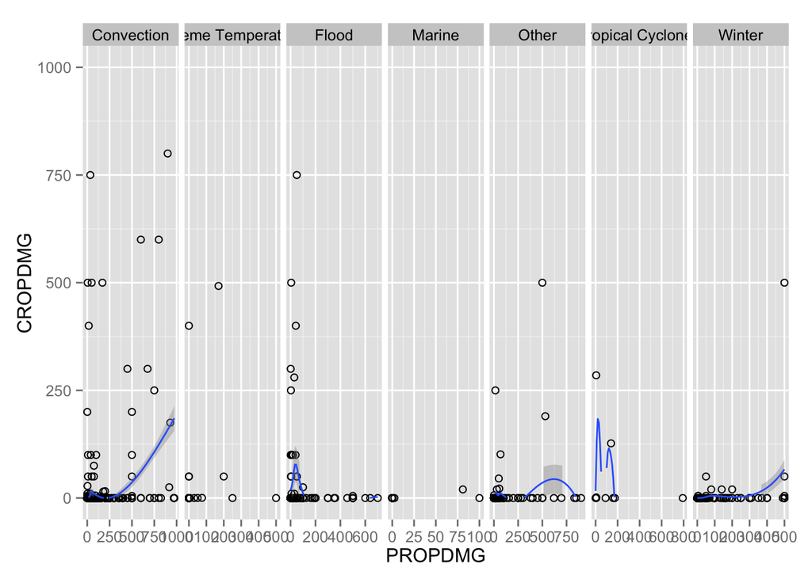

```r
fatalities<-subset(smallData,FATALITIES > 0 & INJURIES > 0)
x<-ggplot(fatalities, aes(x=PROPDMG,y=CROPDMG,))+geom_point(shape=1)+geom_smooth()
x + facet_grid(. ~ category,scale="free")+scale_y_continuous(limits=c(0,1000))
```

The x-axis depicts property damage, while the y axis shows corresponding crop damage. I have faceted accroding to categories of events taking place so as to get more perspective into relationship between events.

## Multivariate Plots

This section will cover more detailed plots and multiple scatter plots togther to find some kind of relationships between variables quickly.

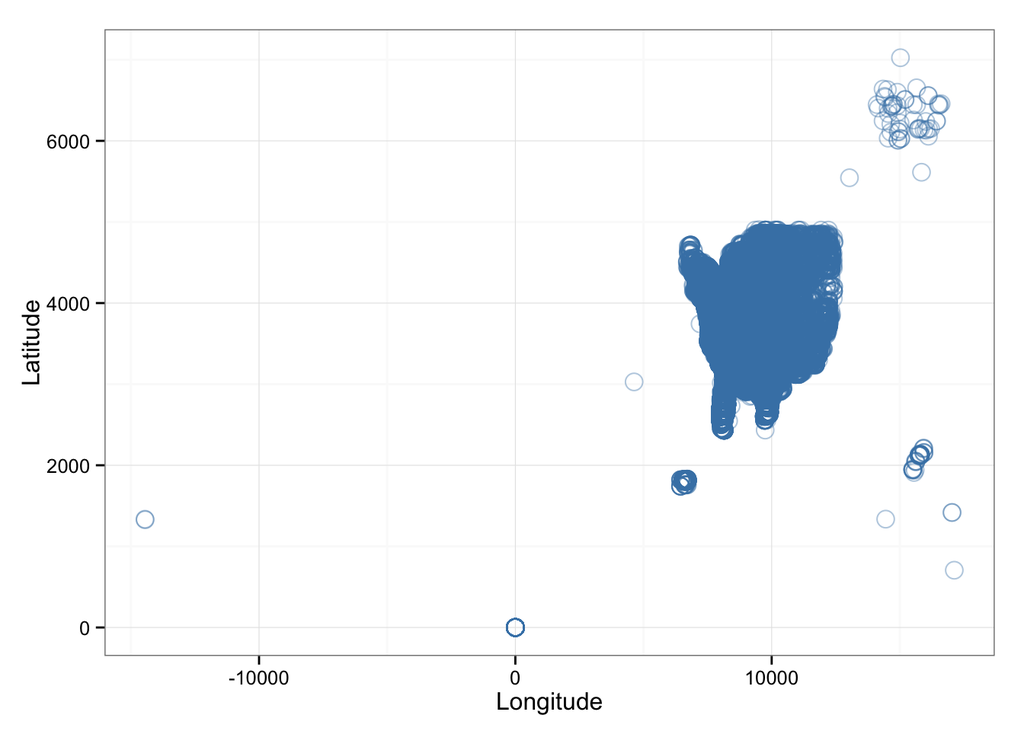

```r
ggplot(smallData, aes(LONGITUDE, LATITUDE, colour = smallData$FATALITIES,100)) + geom_point(size = 4,shape = 1, colour = "steelblue", alpha = 0.4) + labs(x = "Longitude", y = "Latitude") + scale_colour_grey() + theme_bw()
```

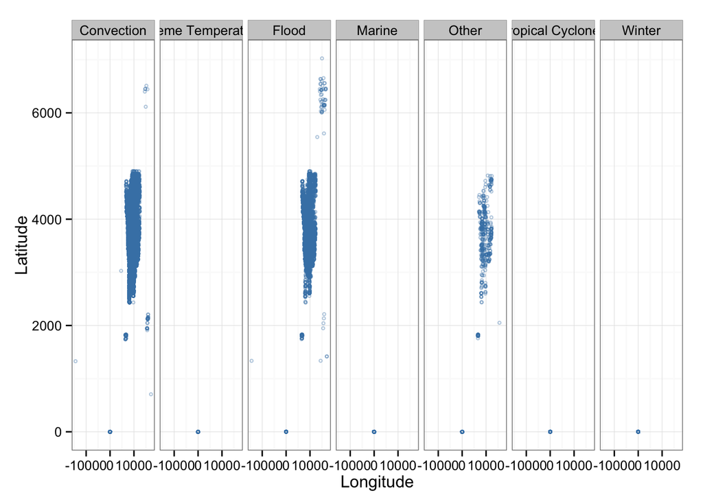

```r
ggplot(smallData, aes(LONGITUDE, LATITUDE, colour = smallData$FATALITIES)) + geom_point(size = 1,shape = 1, colour = "steelblue", alpha = 0.4) + labs(x = "Longitude", y = "Latitude") + scale_colour_grey() + theme_bw()+facet_grid(~category)
```

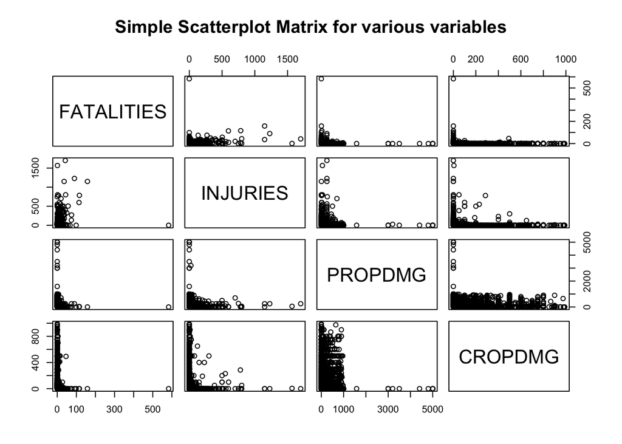

```r
pairs(~FATALITIES+INJURIES+PROPDMG+CROPDMG,data=smallData,
    main="Simple Scatterplot Matrix for various variables")
```